# Damerla_Surya_midterm

Suma

3/27/2020

# 1 Introduction

This is an analysis report of the Coronavirus (COVID-19).The 2019-nCoV is a contagious coronavirus that hailed from Wuhan, China. This new strain of virus has striked fear in many countries as cities are quarantined and hospitals are overcrowded. This dataset from John Hopkin’s university will help us understand how 2019-nCoV is spread around the world.

## 1.1 Variables

There are three time series datasets which recorded the numbers of confirmed cases,deaths and the recoveries of COVID-19 corresponding to country/state/region from 1/22 to 3/21.

- Variables in the original datasets include :
  - Province/State : contains the state value
  - Country/Region : contains the country value
  - Lat : contains the latitude value of the region
  - Long : contains the longitude co-ordinate value of the region
  - Rest of the columns are dated from 1/22 - 3/21 : contains the value of reported cases

The datasets are cleaned using the tidyverse libraries and they are merged into a single dataset.

- Variables after tidying and merging the datasets:
  - state : renamed column of Province/State
  - country : renamed column of Country/Region
  - Lat : same as the original dataset
  - Long : same as the original dataset
  - Date : It is a newly created variable containing all the column headers of each Date
  - Confirmed : contains the sum of all the confirmed cases for a given date and region
  - Deaths : contains the sum of all the number of deaths for a given date and region
  - Recovered : contains the sum of all the number of recovered patients for a given date and region

# 2 Worldwide Analysis

## 2.1 Trend of cases worldwide

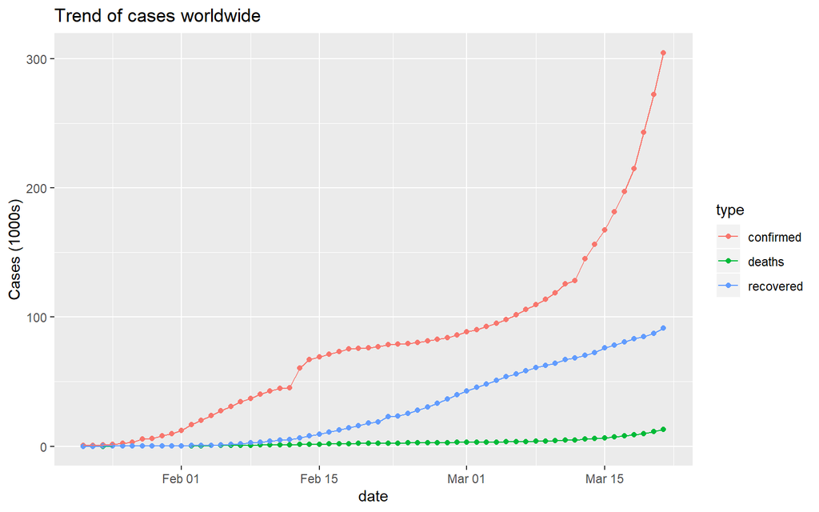

- Observations:
  - The number of confirmed cases are gradually increasing day by day.
  - On January 22nd, there were 555 confirmed cases, 17 deaths and 28 recoveries worldwide. It is unfortunate and shocking that these numbers grew to 304524 confirmed cases, 12973 deaths and 91499 recoveries as of March 21st within a span of two months.

## 2.2 Cases worldwide by date

Three new variables have been introduced: active (confirmed – recover – deaths), recovery % (recover/confirmed), and mortality % (deaths/confirmed) to get more insights into the effect of corona

Table 1: Cases worldwide by date

| date | confirmed | deaths | recovered | active | recovery % | mortality % |
| --- | --- | --- | --- | --- | --- | --- |
| 2020-01-22 | 555 | 17 | 28 | 510 | 5.045 | 3.063 |
| 2020-01-23 | 653 | 18 | 30 | 605 | 4.594 | 2.757 |
| 2020-01-24 | 941 | 26 | 36 | 879 | 3.826 | 2.763 |
| 2020-01-25 | 1434 | 42 | 39 | 1353 | 2.720 | 2.929 |
| 2020-01-26 | 2118 | 56 | 52 | 2010 | 2.455 | 2.644 |
| 2020-01-27 | 2927 | 82 | 61 | 2784 | 2.084 | 2.802 |
| 2020-01-28 | 5578 | 131 | 107 | 5340 | 1.918 | 2.349 |
| 2020-01-29 | 6166 | 133 | 126 | 5907 | 2.043 | 2.157 |
| 2020-01-30 | 8234 | 171 | 143 | 7920 | 1.737 | 2.077 |
| 2020-01-31 | 9927 | 213 | 222 | 9492 | 2.236 | 2.146 |
| 2020-02-01 | 12038 | 259 | 284 | 11495 | 2.359 | 2.152 |

## 2.3 Cases by country table

Three new variables have been introduced: active (confirmed – recover – deaths), recovery % (recover/confirmed), and mortality % (deaths/confirmed) to get more insights into the effect of corona country wise

Table 2: Cases worldwide by country

| country | confirmed | deaths | recovered | active | recovery % | mortality % |
| --- | --- | --- | --- | --- | --- | --- |
| China | 81305 | 3259 | 71857 | 6189 | 88.380 | 4.008 |
| Italy | 53578 | 4825 | 6072 | 42681 | 11.333 | 9.006 |
| US | 25489 | 307 | 0 | 25182 | 0.000 | 1.204 |
| Spain | 25374 | 1375 | 2125 | 21874 | 8.375 | 5.419 |
| Germany | 22213 | 84 | 233 | 21896 | 1.049 | 0.378 |
| Iran | 20610 | 1556 | 7635 | 11419 | 37.045 | 7.550 |
| France | 14431 | 562 | 12 | 13857 | 0.083 | 3.894 |
| Korea, South | 8799 | 102 | 1540 | 7157 | 17.502 | 1.159 |
| Switzerland | 6575 | 75 | 15 | 6485 | 0.228 | 1.141 |
| United Kingdom | 5067 | 234 | 67 | 4766 | 1.322 | 4.618 |
| Netherlands | 3640 | 137 | 2 | 3501 | 0.055 | 3.764 |
| Belgium | 2815 | 67 | 263 | 2485 | 9.343 | 2.380 |

- Observations:
  - China has the most confirmed cases followed by Italy, US and Spain. However, it is interesting to note that China has 88% recovery rate, whereas Italy, US and Spain have about 11%, 0 and 8% recovery rates respectively.
  - Italy has the maximum number of deaths with 9% mortality rate and 11% recovery rate.

## 2.4 Trend of Cases Excluding China

A useful analysis is to show the worldwide cases excluding China since it has the most number of confirmed cases

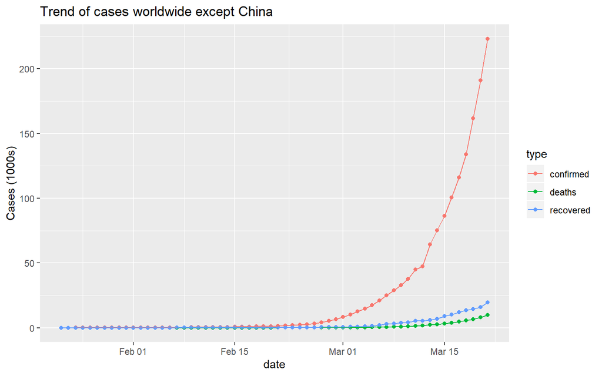

- Observations:
  - The identified cases is exponentially growing from March 1 and we can see a peak in the recovered cases as well.
  - There are a total of 3259 deaths in China till March 21st.

## 2.5 Cases worldwide by date, excluding China

Table 3: Cases worldwide by date except China

| date | confirmed | deaths | recovered | active | recovery % | mortality % |
| --- | --- | --- | --- | --- | --- | --- |
| 2020-01-22 | 7 | 0 | 0 | 7 | 0.000 | 0 |
| 2020-01-23 | 10 | 0 | 0 | 10 | 0.000 | 0 |
| 2020-01-24 | 21 | 0 | 0 | 21 | 0.000 | 0 |
| 2020-01-25 | 28 | 0 | 0 | 28 | 0.000 | 0 |
| 2020-01-26 | 43 | 0 | 3 | 40 | 6.977 | 0 |
| 2020-01-27 | 50 | 0 | 3 | 47 | 6.000 | 0 |
| 2020-01-28 | 69 | 0 | 6 | 63 | 8.696 | 0 |
| 2020-01-29 | 79 | 0 | 6 | 73 | 7.595 | 0 |
| 2020-01-30 | 93 | 0 | 8 | 85 | 8.602 | 0 |
| 2020-01-31 | 125 | 0 | 8 | 117 | 6.400 | 0 |
| 2020-02-01 | 147 | 0 | 9 | 138 | 6.122 | 0 |

- Observations:
  - There’s a drastic difference in the number of confirmed cases worldwide without China in the initial stages, however today there are 223219 confirmed cases worldwide except China.
  - The recovery rate ranges between 0 to 16.490% with average of 8.96 % without China whereas otherwise the range is 1% to 55% with average of 25.87 % rates.

# 3 U.S. Analysis. Analyze the cases in the U.S.

## 3.1 Trend in the U.S

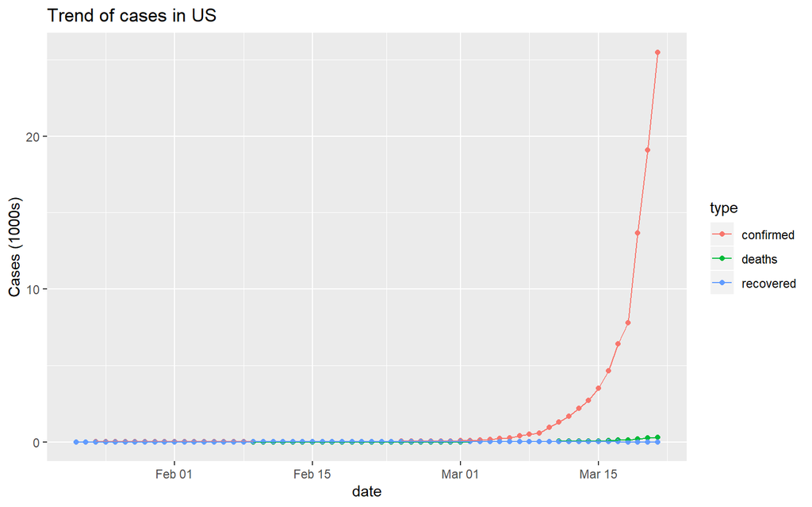

## 3.2 Table of cases in the U.S. by date

Table 4: Cases in the U.S. by date

| date | confirmed | deaths | recovered | active | recovery % | mortality % |
| --- | --- | --- | --- | --- | --- | --- |
| 2020-01-22 | 1 | 0 | 0 | 1 | 0 | 0 |
| 2020-01-23 | 1 | 0 | 0 | 1 | 0 | 0 |
| 2020-01-24 | 2 | 0 | 0 | 2 | 0 | 0 |
| 2020-01-25 | 2 | 0 | 0 | 2 | 0 | 0 |
| 2020-01-26 | 5 | 0 | 0 | 5 | 0 | 0 |
| 2020-01-27 | 5 | 0 | 0 | 5 | 0 | 0 |
| 2020-01-28 | 5 | 0 | 0 | 5 | 0 | 0 |
| 2020-01-29 | 5 | 0 | 0 | 5 | 0 | 0 |
| 2020-01-30 | 5 | 0 | 0 | 5 | 0 | 0 |
| 2020-01-31 | 7 | 0 | 0 | 7 | 0 | 0 |
| 2020-02-01 | 8 | 0 | 0 | 8 | 0 | 0 |

## 3.3 Table of cases in the U.S. by state

Table 5: Cases in the U.S by state

| state | confirmed | deaths | recovered | active | recovery % | mortality % |
| --- | --- | --- | --- | --- | --- | --- |
| New York | 11710 | 60 | 0 | 11650 | 0 | 0.512 |
| Washington | 1793 | 94 | 0 | 1699 | 0 | 5.243 |
| California | 1364 | 24 | 0 | 1340 | 0 | 1.760 |
| New Jersey | 1327 | 16 | 0 | 1311 | 0 | 1.206 |
| Michigan | 788 | 5 | 0 | 783 | 0 | 0.635 |
| Illinois | 753 | 6 | 0 | 747 | 0 | 0.797 |
| Florida | 659 | 13 | 0 | 646 | 0 | 1.973 |
| Louisiana | 585 | 16 | 0 | 569 | 0 | 2.735 |
| Texas | 581 | 5 | 0 | 576 | 0 | 0.861 |
| Massachusetts | 525 | 1 | 0 | 524 | 0 | 0.190 |
| Georgia | 507 | 14 | 0 | 493 | 0 | 2.761 |
| Pennsylvania | 396 | 2 | 0 | 394 | 0 | 0.505 |

- Observations:
  - New York with 11710 cases is the most infected state in the US followed by Washington, California and New Jersey at 1793,1364 and 1327 cases respectively.
  - Washington with 1793 has shocking 94 number of deaths whereas New York seems to have it contained with only 60 deaths in 11710 confirmed cases.

# 4 Analysis

## 4.1 Confirmed vs Deaths in top 10 countries

The below graph compares the number of confirmed cases vs the number of deaths in the top 10 countries exposed to COVID-19.The labelled countries have seen more than 500 deaths as of March 21st.

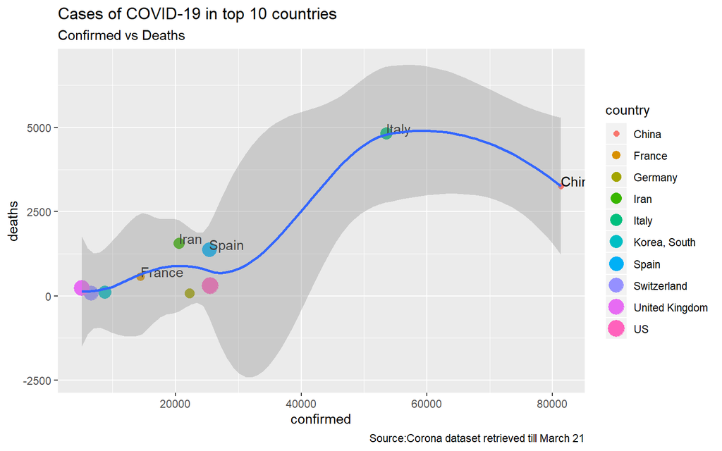

+ Observations:  
* The maximum number of deaths in a country are 4825 from Italy. * Even though US and Spain have seen similar number of confirmed cases, Spain has relatively more number of deaths

## 4.2 Worldwide map of confirmed cases

Below map shows the confirmed cases across the world.

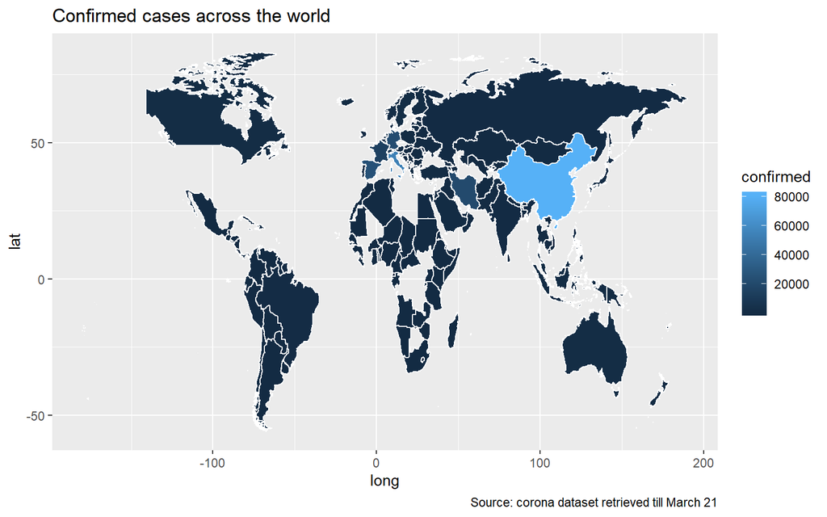

## 4.3 Interactive map of active cases

An interactive map of active cases as of March 21st is shown below. Hover on each country to see the number of active cases.The color gradient indicates the number of active cases with darker color indicating higher cases.

[interactive chart not shown]

## 4.4 Journey of corona virus

Table 6.1: First 12 countries exposed to ncov-19

| date | country | confirmed | deaths | recovered |
| --- | --- | --- | --- | --- |
| 2020-01-22 | China | 548 | 17 | 28 |
| 2020-01-22 | Japan | 2 | 0 | 0 |
| 2020-01-22 | Korea, South | 1 | 0 | 0 |
| 2020-01-22 | Taiwan* | 1 | 0 | 0 |
| 2020-01-22 | Thailand | 2 | 0 | 0 |
| 2020-01-22 | US | 1 | 0 | 0 |
| 2020-01-23 | China | 643 | 18 | 30 |
| 2020-01-23 | Japan | 1 | 0 | 0 |
| 2020-01-23 | Korea, South | 1 | 0 | 0 |
| 2020-01-23 | Singapore | 1 | 0 | 0 |
| 2020-01-23 | Taiwan* | 1 | 0 | 0 |
| 2020-01-23 | Thailand | 3 | 0 | 0 |

# 5 Conclusion

## 5.2 Do your findings match what you hear in the media?

Yes,I find that most of the findings match the media news.

# 6 References

[1] [CSSEGISandData/COVID-19. (n.d.). GitHub. Retrieved March 22, 2020](https://github.com/CSSEGISandData/COVID-19)  
[2] [Gather :TidyVerse](https://tidyr.tidyverse.org/reference/gather.html)  
[3] [Pivot data](https://www.storybench.org/pivoting-data-from-columns-to-rows-and-back-in-the-tidyverse)  
[4] [Knitr](https://www.rdocumentation.org/packages/knitr/versions/1.28/topics/kable)  
[5] [HighCharter](https://www.datacamp.com/community/tutorials/data-visualization-highcharter-r)  
[6] [Corona: World Health Organisation](https://www.who.int/emergencies/diseases/novel-coronavirus-2019)  
[7] [Corona updates](https://www.cdc.gov/coronavirus/2019-ncov/cases-updates/summary.html)